# CCLHDME R Introduction

2022-07-12

```r
# clean with CSS
```

**[Jaspo comment: Please check “CopyOf..HTML” file. What do you think about the theme, adding a table of contents, and the Intro section? Also, did you you want me to list out the instructions for installing R/RStudio in Windows here in this document, or does providing the link to an instruction guide suffice?]**

### This R markdown document is a guide and tool for the workshop, and a way to share learning materials and other resources

### The learning approach is watching leader live demonstrations, then participants doing the same things live. Staring with immediately using R and R Studio as basically as possible for practical things, then cycle “backwards” for some concepts and options, then applying/using those, and repeat. And, pointing out and linking to additional learning resources and tools at each stage. Sound good?

[Jaspo] * what is R * installing R * Visit this website https://www.r-project.org/ and download the latest version of R suitable for your computer. * & install R

- what is R Studio
- installing R Studio
- Visit this website https://rstudio.com/products/rstudio/download/ and download the latest free Desktop version of RStudio suitable for your computer.
- & install R Studio

[15 minutes]

[end Jaspo]

@ script 1 (console and script) **[Jaspo Comment: Should I put anything in here? We moved the items from here into the “Session 1” section]**

@ script 2 (console, then in script file) **[Jaspo Comment: I won’t be running any code in the R console in this script. In fact, due to limited time, I won’t be live coding at all in this script. I’m just planning to walk-through the code.]**

### what are R packages

**[Jaspo comment: I’ll be explaining this in script 2]**

#### installing R packages

**[Jaspo comment: I’ll show how to install ggplot and dplyr in script 2]**

@ script 3 (script file)

- install a couple packages
- read some data
- wrangle some data
- ggplot some data

# Concepts and options for Session 1

- R console
- using R as a calculator - mathematical operators
- R script files
- simplest **objects** in R
  - vectors of length 1 (atomic vectors)
  - vectors
  - data types
    - numeric
    - character
    - logical (Boolean)
  - data structure
    - vectors
    - data.frames
- math with simple objects
- R (mathematical) operators
- functions
  - arguments
  - “help” documentation
- base R
  - charts
- reading data
- using a script file to save code and start a “program”
- looking at that data
  - common functions
    - dim()
    - head()
    - tail()
    - View()
    - str()
    - names()
    - unique()
    - table()
    - min()
    - max()
    - range()
    - mean()
  - plot with base R
  - etc.
- installing and loading packages
- tidyverse
  - dplyr()
    - verbs - [find best reference resource for this]
    - pipes
  - ggplot2()
  - readr()
  - lubridate()
- using an R Project (?)
- thousands of other packages
  - summarytools() - easy frequencies, “cross-tables”, and summary of a data.frame
  - outbreaks() - line-listed data from a bunch of real outbreaks
  - epikit() or epitools() or something else

joins (above or below)

## Some important concepts and options - Future sessions

- options for installing packages
- working with paths (?)
- data type precidence
- Rules and best practices for naming objects
- more R object types
  - data.frames and tibbles
  - lists
  - class()
- subsetting/indexing
- functions
- markdown
  - https://skylab.cdph.ca.gov/communityBurden/_w_21945fed/xMDA/2020_Excess_Mortality.html
- ifelse() and other logical evaluation
- tables
- advanced data manipulation
- epidemiologic statistics and modeling
- shiny
- GIS
- shiny with GIS
- thousands of other packages
  - reading data
    - EXCELL
    - SAS
  - Shiny - interactive visualizations and web sites
  - visual display
  - epidemiology
  - disease surveillance
  - outbreaks
  - GIS
    - tmap()
  - data analysis and modeling
  - tables
- GIT

Some important concepts and options - Future sessions * apply and loops

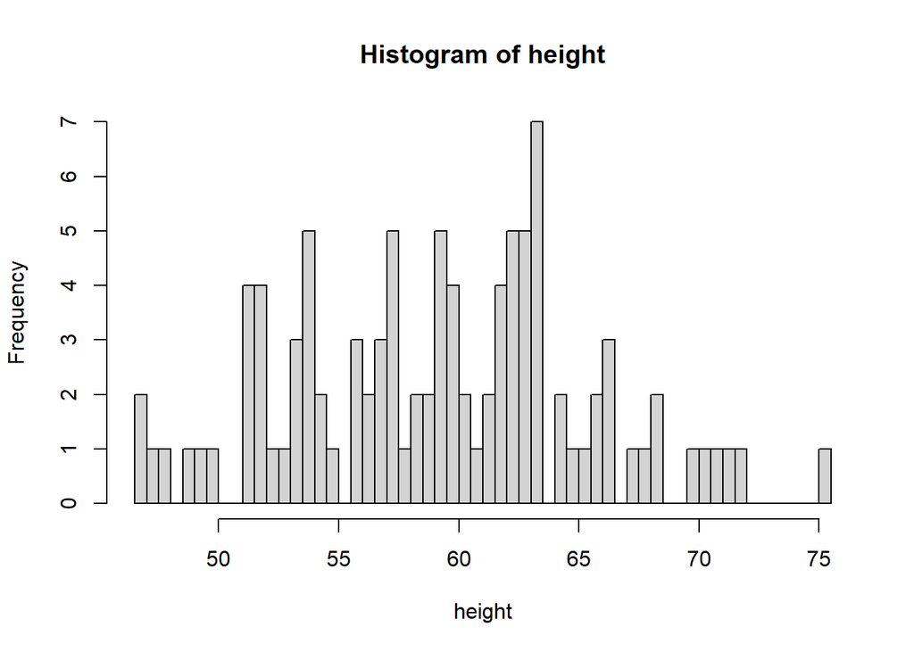

```r
height <- rnorm(n=100, mean= 60, sd = 6)
weight <- height*1.2 +  rnorm(n=100, mean= 10, sd = 6)
hist(height, breaks=50)
```

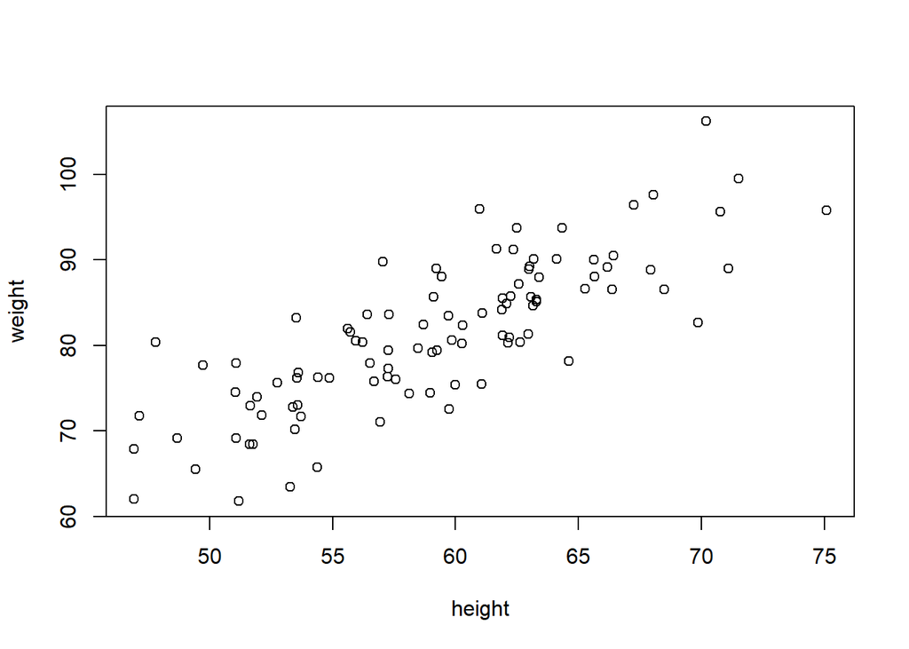

```r
plot(height, weight)
```

[Jaspreet and michael both show finding info from the resouces below something like twice]

### Many great resources for other approaches to learning R, and learning R for epidemiology

[Michael check]

Hadley Wickham R for Data Science book

- https://r4ds.had.co.nz/

Applied Epi:

- Home: https://appliedepi.org/
- The Epidemiologist R Handbook: https://www.epirhandbook.com/en/
- Free self-paced tutorial series: https://appliedepi.org/tutorial/
  - need free account
  - basics: https://tutorials.appliedepi.org/app/basics
  - data preparation
  - data cleaning
  - basics of data visualization in R
  - summary tables

CCLHDME 2019 workshop

R Studio cheat sheets: https://www.rstudio.com/resources/cheatsheets/

Google

YouTube

Stackoverflow – https://stackoverflow.com/

https://community.rstudio.com/